# 20212_M2.855_PEC3_Enunciado

[figure not shown]

M2.855 · Modelos avanzados de minería de datos · PEC3

2021-2 · Máster universitario en Ciencia de datos (*Data science*)

Estudios de Informática, Multimedia y Telecomunicación

# PEC 3: Métodos supervisados

En esta práctica veremos diferentes métodos supervisados y trataremos de optimizar diferentes métricas. Veremos como los diferentes modelos clasifican los puntos y con cuales obtenemos mayor precisión. Después aplicaremos todo lo que hemos aprendido hasta ahora a un dataset nuevo simulando un caso práctico real.

1. Exploración de algoritmos supervisados
   1. Naive-Bayes
   2. $k$ vecinos más próximos
   3. Support vector machines
   4. Árboles de decisión
   5. Random forest / Gradient boosting
2. Implementación del caso práctico
   1. Análisis descriptivo
   2. Preprocesamiento de los datos
   3. Entrenamiento del modelo
   4. Predicción de nuevos casos

**Importante: Cada uno de los ejercicios puede suponer varios minutos de ejecución, por lo que la entrega se hará en formato notebook y en formato html donde se vea el código y los resultados, junto con los comentarios de cada ejercicio. Para exportar el notebook a html se puede hacer desde el menú File $\to$ Download as $\to$ HTML.**

**Nombre y apellidos:** Victor H. Ayala Sánchez

```python
import numpy as np
import pandas as pd
import seaborn as sns

from sklearn import datasets
from sklearn.ensemble import GradientBoostingClassifier, RandomForestClassifier
from sklearn.linear_model import LogisticRegression
from sklearn.metrics import accuracy_score, confusion_matrix
from sklearn.model_selection import train_test_split, GridSearchCV
from sklearn.naive_bayes import GaussianNB
from sklearn.neighbors import KNeighborsClassifier
from sklearn.preprocessing import OneHotEncoder
from sklearn.svm import SVC
from sklearn.tree import DecisionTreeClassifier, export_graphviz
from sklearn.utils import check_random_state

# Visualizar árboles
from IPython.display import Image
import pydotplus
from six import StringIO

# Visualización.
import matplotlib as mpl
from matplotlib.colors import ListedColormap
import matplotlib.pyplot as plt

%matplotlib inline
```

## 1. Exploración de algoritmos supervisados (5 puntos)

El conjunto de datos CIRCLES consiste en puntos en un plano que forman dos círculos, de aquí el nombre de "circles". Cada círculo corresponde a un grupo diferente [0, 1].

El siguiente código generará 1.000 puntos y hace un gràfico para visualizar los dos círculos (con colores diferentes para cada grupo).

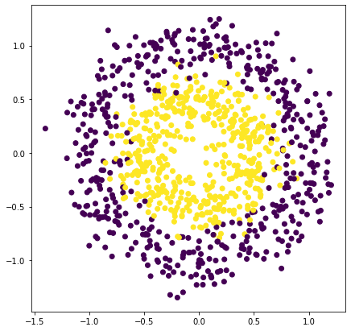

```python
df = datasets.make_circles(n_samples=1000, factor=.5, noise=.15, random_state=42)
df_x = [x[0] for x in df[0]]
df_y = [x[1] for x in df[0]]
df_group = df[1]

fig, ax = plt.subplots(figsize=(7,7))
ax.scatter(df_x, df_y, c=df_group)
```

Antes de aplicar ningún modelo, tenemos que separar los datos entre el conjunto de *train* y de *test*. Siempre trabajaremos sobre el conjunto de *train* y evaluaremos los resultados en *test*.

**Implementación:** Dividid el _dataset_ en dos subconjuntos, __*train*__ (80% de los datos) y __*test*__ (20% de los datos). Nombrad los conjuntos como: X_train, X_test, y_train, y_test. Utilizad la opción `random_state = 24`. Podéis utilizar la implementación `train_test_split` de `sklearn`.

Como los datos orginales vienen en una tupla los paso a una estructura dataframe para trabajar de una forma más cómoda

```python
type(df)
```

```
tuple
```

```python
df_2 = pd.DataFrame({'df_x': df_x,
                   'df_y': df_y,
                   'df_group': df_group
    })
df_2.sample(2)
```

|  | df_x | df_y | df_group |
| --- | --- | --- | --- |
| 600 | 1.134785 | 0.082414 | 0 |
| 724 | -0.927017 | -0.547356 | 0 |

```python
df_2.shape
```

```
(1000, 3)
```

```python
X_train, X_test, y_train, y_test = train_test_split(df_2[["df_x","df_y"]],
                                                    df_2["df_group"],
                                                    test_size=0.20,
                                                    random_state=24)
```

A lo largo de los ejercicios aprenderemos a ver gráficamente las fronteras de decisión que nos devuelven los diferentes modelos. Para ello utilizaremos la función definida a continuación, que sigue los siguientes pasos:

- Crear una *meshgrid* con los valores mínimo y máximo de 'x' e 'y'.
- Predecir el clasificador con los valores de la *meshgrid*.
- Hacer un *reshape* de los datos para tener el formato correspondiente.

Una vez hecho esto, ya podemos hacer el gráfico de las fronteras de decisión y añadir los puntos reales. Así veremos las áreas que el modelo considera que son de una clase y las que considera que son de otra. Al poner encima los puntos veremos si los clasifica correctamente en el área que les corresponde. También veremos las areas de indecisión, casos en los que el modelo no se inclina ni hacia una clase ni hacia otra (o si que se inclina pero no lo tiene 100% claro), estas seran blanquinosas.

```python
# Vamos a crear la meshgrid con los valores mínimos y máximos de los ejes x e y
x_min, x_max = min(df_x)-0.1, max(df_x)+0.1
y_min, y_max = min(df_y)-0.1, max(df_y)+0.1

def plot_decision_boundaries(x, y, labels, model,
                             x_min=x_min,
                             x_max=x_max,
                             y_min=y_min,
                             y_max=y_max,
                             grid_step=0.02):

    xx, yy = np.meshgrid(np.arange(x_min, x_max, grid_step),
                         np.arange(y_min, y_max, grid_step))

    # Precedimos con el clasificador con los valores de la meshgrid
    Z = model.predict_proba(np.c_[xx.ravel(), yy.ravel()])[:,1]

    # Hacemos reshape para tener el formato correcto.
    Z = Z.reshape(xx.shape)

    # Seleccionamos una paleta de color.
    arr = plt.cm.coolwarm(np.arange(plt.cm.coolwarm.N))
    arr_hsv = mpl.colors.rgb_to_hsv(arr[:,0:3])
    arr_hsv[:,2] = arr_hsv[:,2] * 1.5
    arr_hsv[:,1] = arr_hsv[:,1] * .5
    arr_hsv = np.clip(arr_hsv, 0, 1)
    arr[:,0:3] = mpl.colors.hsv_to_rgb(arr_hsv)
    my_cmap = ListedColormap(arr)

    # Dibujamos las fronteras de decisión.
    fig, ax = plt.subplots(figsize=(7,7))
    plt.pcolormesh(xx, yy, Z, cmap=my_cmap, shading='auto')

    # Añadimos los puntos.
    ax.scatter(x, y, c=labels, cmap='coolwarm')
    ax.set_xlim(xx.min(), xx.max())
    ax.set_ylim(yy.min(), yy.max())
    ax.grid(False)
```

### 1.1. Gaussian Naïve Bayes

El objetivo de este primer ejercicio es entender el funcionamiento del algoritmo Naïve-Bayes, un algoritmo peculiar ya que se basa completamente en teoría de probabilidades.

**Implementación:** Con el dataset de _train_, entrenad un modelo Naïve-Bayes y representad gráficamente la frontera de decisión con el de _test_. Podéis utilizar el clasificador **GaussianNB** de `sklearn`. Calculad el _accuracy_ del modelo obtenido sobre _train_ y _test_ y la matriz de confusión sobre _test_. Podéis utilizar `accuracy_score` y `confusion_matrix` del paquet `metrics` de `sklearn`.

```python
gnb = GaussianNB()
```

```python
gnb.fit(X_train, y_train)
y_pred = gnb.predict(X_test)
```

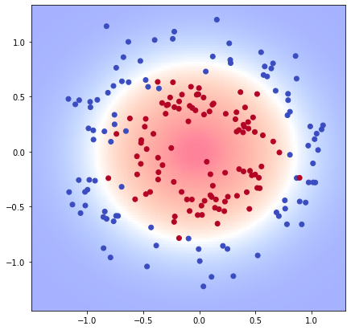

```python
plot_decision_boundaries(X_test["df_x"], X_test["df_y"], y_test, gnb)
```

```python
from sklearn.metrics import accuracy_score

y_pred_train = gnb.predict(X_train)

print("Accuracy del modelo sobre los datos test: {}".format(accuracy_score(y_test, y_pred)))
print("Accuracy del modelo sobre los datos train: {}".format(accuracy_score(y_train, y_pred_train)))
```

```
Accuracy del modelo sobre los datos test: 0.96
Accuracy del modelo sobre los datos train: 0.945
```

```python
target_names = [1,0]

cm = pd.DataFrame(
    confusion_matrix(y_test, y_pred),
    index= target_names,
    columns=target_names
)
cm
```

[output not shown]

```python
from sklearn.metrics import classification_report

print(classification_report(y_test, y_pred))
```

```
              precision    recall  f1-score   support

           0       0.95      0.97      0.96        99
           1       0.97      0.95      0.96       101

    accuracy                           0.96       200
   macro avg       0.96      0.96      0.96       200
weighted avg       0.96      0.96      0.96       200
```

**Análisis:** Análisis del ejercicio. - ¿Cómo son las fronteras de decisión? ¿Tiene sentido que tengan esta forma con el algoritmo utilizado? - ¿Cómo son las predicciones obtenidas sobre el conjunto de test?

- Con respecto a las fronteras de decisión se observa que estas son uniformea y la zona de incertidumbre además de también ser uniforme no es grande.
- En lo que se refiere a las predicciones sobre el cojunto test, el modelo tiene un accuracy alto y una precisión alta. Es decir clasifica de forma correcta la gran mayoría de los registros y es capaz de detectar las dos clases también de forma correcta.

### 1.2. KNN

El objetivo de este segundo ejercicio es entender el funcionamiento del KNN, intuir sus principales ventajas o desventajas y entender la influencia de los parámetros de los que está compuesto.

K-Nearest-Neighbor es un algoritmo basado en instancia de tipo supervisado.

Vamos a ver qué significa esto:

- Supervisado: tenemos etiquetado nuestro conjunto de datos de entrenamiento, con la clase o resultado esperado.
- Basado en instancia (*Lazy Learning*): Esto significa que nuestro algoritmo no aprende explícitamente un modelo (como por ejemplo en Regresión Logística o árboles de decisión), sino que memoriza las instancias de entrenamiento que son utilizadas como "conocimiento" para la fase de predicción.

¿Cómo funciona KNN?

- Calculamos la distancia entre el ítem a clasificar y los demás ítems del dataset de entrenamiento.
- Seleccionamos los "k" elementos más cercanos, es decir, con menor distancia, según la distancia que utilizamos (euclídea, coseno, manhattan, etc).
- Por último realizamos una "votación de mayoría" entre los k puntos: los de la clase que "dominan" decidirán su clasificación final.

**Implementación:** Con el dataset de _train_, entrenad un modelo KNN con `n_neighbors = 2` y representad gráficamente la frontera de decisión con el de _test_. Podéis utilizar el clasificador **KNeighborsClassifier** de `sklearn`.

```python
nearest_neighbors = KNeighborsClassifier(n_neighbors=2)
nearest_neighbors.fit(X_train, y_train)
```

```
KNeighborsClassifier(n_neighbors=2)
```

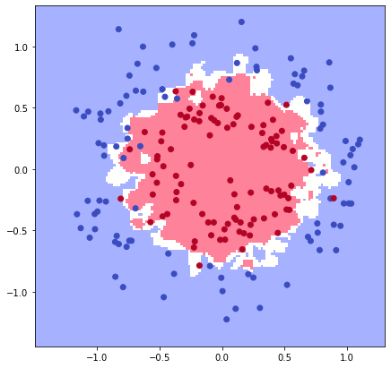

```python
plot_decision_boundaries(X_test["df_x"], X_test["df_y"], y_test, nearest_neighbors)
```

En el modelo entrenado, hemos fijado el parámetro `n_neighbors` de forma arbitraria. Pero podría ser que con otro valor obtuviéramos una mejor predicción.

Para conocer el valor óptimo de los parámetros de un modelo (*hyperparameter tunning*) se suele utilizar una búsqueda de rejilla (*grid search*). Es decir, entrenar un modelo para cada combinación de hiperparámetros posible y evaluarlo utilizando validación cruzada (*cross validation*) con 4 particiones estratificadas. Posteriormente, se elige la combinación de hiperparàmetres que mejores resultados haya obtenido.

En este caso sólo queremos optimizar un hiperparámetro:

**Implementación:** Cálculo del valor óptimo del hiperparámetro _k_ (`n_neighbors`). Utilizad una búsqueda de rejilla con validación cruzada para encontrar el valor óptimo de _k_. Por cada valor, calculad su promedio y la desviación estándar. Implementad un _heatmap_ para visualizar la precisión según los diferentes valores del hiperparámetro. Puede utilizar el módulo `GridSearchCV` de `sklearn` el cálculo del mejor hiperparámetro, y `heatmap` de `Seaborn`.

```python
from sklearn.model_selection import GridSearchCV
```

```python
numberNN = list(range(1,10))
param_grid = {"n_neighbors": numberNN}

knn_models_1 = GridSearchCV(KNeighborsClassifier(),
                            param_grid = param_grid,
                            scoring = ['accuracy', 'precision'], refit=False, cv = 4, n_jobs=-1)

knn_models_1.fit(X_train, y_train)
```

```
GridSearchCV(cv=4, estimator=KNeighborsClassifier(), n_jobs=-1,
             param_grid={'n_neighbors': [1, 2, 3, 4, 5, 6, 7, 8, 9]},
             refit=False, scoring=['accuracy', 'precision'])
```

```python
# Top 5 Models
TopModels = pd.DataFrame(knn_models_1.cv_results_)
TopModels.head(2)
```

|  | mean_fit_time | std_fit_time | mean_score_time | std_score_time | param_n_neighbors | params | split0_test_accuracy | split1_test_accuracy | split2_test_accuracy | split3_test_accuracy | mean_test_accuracy | std_test_accuracy | rank_test_accuracy | split0_test_precision | split1_test_precision | split2_test_precision | split3_test_precision | mean_test_precision | std_test_precision | rank_test_precision |
| --- | --- | --- | --- | --- | --- | --- | --- | --- | --- | --- | --- | --- | --- | --- | --- | --- | --- | --- | --- | --- |
| 0 | 0.007252 | 0.001090 | 0.036254 | 0.018296 | 1 | {'n_neighbors': 1} | 0.910 | 0.905 | 0.900 | 0.91 | 0.90625 | 0.004146 | 8 | 0.910000 | 0.926316 | 0.908163 | 0.893204 | 0.909421 | 0.011730 | 9 |
| 1 | 0.006497 | 0.000495 | 0.022006 | 0.007034 | 2 | {'n_neighbors': 2} | 0.905 | 0.885 | 0.905 | 0.91 | 0.90125 | 0.009601 | 9 | 0.965517 | 0.952941 | 0.955056 | 0.917526 | 0.947760 | 0.018094 | 1 |

```python
# Top de modelos por accuracy
TopModels[["param_n_neighbors", "mean_test_accuracy",
           "std_test_accuracy","rank_test_accuracy"]].sort_values(by = "rank_test_accuracy",
                                                                  ascending=True).head()
```

|  | param_n_neighbors | mean_test_accuracy | std_test_accuracy | rank_test_accuracy |
| --- | --- | --- | --- | --- |
| 6 | 7 | 0.93500 | 0.011726 | 1 |
| 7 | 8 | 0.93500 | 0.012748 | 1 |
| 8 | 9 | 0.93375 | 0.012437 | 3 |
| 5 | 6 | 0.93250 | 0.020156 | 4 |
| 4 | 5 | 0.93125 | 0.017093 | 5 |

```python
# Top de modelos por accuracy
TopModels[["param_n_neighbors", "mean_test_precision",
           "std_test_precision","rank_test_precision"]].sort_values(by = "rank_test_precision",
                                                                  ascending=True).head()
```

|  | param_n_neighbors | mean_test_precision | std_test_precision | rank_test_precision |
| --- | --- | --- | --- | --- |
| 1 | 2 | 0.947760 | 0.018094 | 1 |
| 3 | 4 | 0.938149 | 0.023648 | 2 |
| 5 | 6 | 0.935014 | 0.024475 | 3 |
| 7 | 8 | 0.929524 | 0.026845 | 4 |
| 4 | 5 | 0.925965 | 0.019304 | 5 |

```python
d = TopModels[["param_n_neighbors", "mean_test_precision", "mean_test_accuracy"]].set_index('param_n_neighbors')
d = d.sort_values(by = ["mean_test_precision", "mean_test_accuracy"], ascending=False)
```

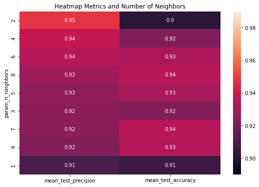

```python
f, ax = plt.subplots(figsize=(9, 6))
sns.heatmap(d, annot=True, ax=ax, vmin=0.89, vmax=0.99).set(title='Heatmap Metrics and Number of Neighbors')
plt.show()
```

El modelo con mayor media de precisión y accuracy tiene como parámetro 6 vecinos

**Implementación:**

Con el mejor hiperparámetro encontrado, volved a entrenar un clasificador KNN (con *train*) y representar las fronteras de decisión con los puntos de *test*.

Calcular el *accuracy* del modelo obtenido sobre *test* y la matriz de confusión. Podéis utilizar `accuracy_score` y `confusion_matrix` de `metrics` de `sklearn`.

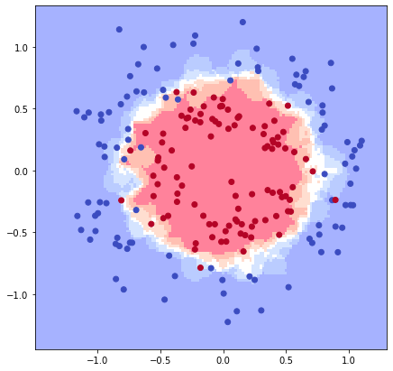

```python
nearest_neighborsBest = KNeighborsClassifier(n_neighbors=6)
nearest_neighborsBest.fit(X_train, y_train)

plot_decision_boundaries(X_test["df_x"], X_test["df_y"], y_test, nearest_neighborsBest)
```

```python
y_pred = nearest_neighborsBest.predict(X_test)
accuracy_score(y_test, y_pred)
```

```
0.94
```

```python
target_names = [1,0]

cm = pd.DataFrame(
    confusion_matrix(y_test, y_pred),
    index= target_names,
    columns=target_names
)
cm
```

[output not shown]

```python
print(classification_report(y_test, y_pred))
```

```
              precision    recall  f1-score   support

           0       0.95      0.93      0.94        99
           1       0.93      0.95      0.94       101

    accuracy                           0.94       200
   macro avg       0.94      0.94      0.94       200
weighted avg       0.94      0.94      0.94       200
```

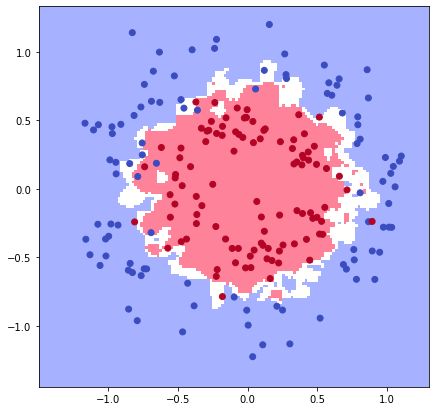

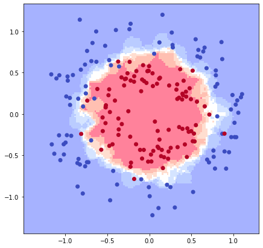

```python
plot_decision_boundaries(X_test["df_x"], X_test["df_y"], y_test, nearest_neighbors)

plot_decision_boundaries(X_test["df_x"], X_test["df_y"], y_test, nearest_neighborsBest)
```

**Análisis:** Análisis del ejercicio: - Comentar los resultados de la búsqueda del mejor hiperparámetro. - ¿Cómo se visualiza gráficamente el cambio del valor `n_neighbors`? ¿Tiene sentido esta diferencia entre los dos gráficos al cambiar el parámetro? - ¿Cómo son las fronteras de decisión? ¿Tiene sentido que tengan esta forma con el algoritmo utilizado? - ¿Cómo son las predicciones obtenidas sobre el conjunto de test?

### 1.3. SVM

Las Support Vector Machine se fundamentan en el *Máximal Margin Classifier*, que a su vez, se basan en el concepto de hiperplano.

En un espacio p-dimensional, un hiperplano se define como un subespacio plano y afín de dimensiones p-1. El término afín significa que el subespacio no debe pasar por el origen. En un espacio de dos dimensiones, el hiperplano es un subespacio de 1 dimensión, es decir, una recta. En un espacio tridimensional, un hiperplano es un subespacio de dos dimensiones, un plano convencional. Para dimensiones p>3 no es intuitivo visualizar un hiperplano, pero el concepto de subespacio con p-1 dimensiones se mantiene.

La definición de hiperplano para casos perfectamente separables linealmente resulta en un número infinito de posibles hiperplanos, lo que hace necesario un método que permita seleccionar uno de ellos como clasificador óptimo.

La solución a este problema consiste en seleccionar como clasificador óptimo al que se conoce como *maximal margin hyperplane* o hiperplano óptimo de separación, que se corresponde con el hiperplano que se encuentra más alejado de todas las observaciones de entrenamiento. Para obtenerlo, se debe calcular la distancia perpendicular de cada observación a un determinado hiperplano. La menor de estas distancias (conocida como margen) determina cómo de lejos está el hiperplano de las observaciones de entrenamiento. El *maximal margin hyperplane* se define como el hiperplano que consigue un mayor margen, es decir, que la distancia mínima entre el hiperplano y las observaciones es lo más grande posible. Aunque esta idea suena razonable, no es posible aplicarla, ya que habría infinitos hiperplanos contra los que medir las distancias. En su lugar, se recurre a métodos de optimización.

El proceso de optimización tiene la peculiaridad de que sólo las observaciones que se encuentran justo al margen o que lo violan influyen sobre el hiperplano. A estas observaciones se les conoce como vectores soporte (*vectors suport*) y son las que definen el clasificador obtenido.

#### Los *kernels* en SVM

Hay veces en que no hay manera de encontrar un hiperplano que permita separar dos clases. En estos casos decimos que las clases no son linealmente separables. Para resolver este problema podemos utilizar el truco del núcleo .

El truco del núcleo (*kernel trick*) consiste en utilizar una dimensión nueva en la que podamos encontrar un hiperplano para separar las clases. Se puede ver un un ejemplo en: https://www.youtube.com/watch?v=OdlNM96sHio

Al igual que en el algoritmo visto anteriormente (KNN), las SVM también dependen de varios hiperparámetros.

En este caso intentaremos optimizar dos hiperparámetros:

- C: es la regularización, es decir, el valor de penalización de los errores en la clasificación. Indica el compromiso entre obtener el hiperplano con el margen más grande posible y clasificar el máximo número de ejemplos correctamente. Probaremos los valores: 0.01, 0.1, 1, 10, 50, 100 y 200.
- gama: coeficiente que multiplica la distancia entre dos puntos en el kernel radial. Para decirlo a "grosso modo", cuanto más pequeño es gama, más influencia tienen dos puntos cercanos. Probaremos los valores: 0.001, 0.01, 0.1, 1 y 10.

Al igual que en el caso anterior, para validar el rendimiento del algoritmo con cada combinación de hiperparámetros utilizaremos validación cruzada (*cross-validation*) con 4 particiones estratificadas.

**Implementación:** Cálcular del valor óptimo de los hiperparámetros _C_ y _gama_. Utilizad una búsqueda de rejilla con validación cruzada para encontrar los valores óptimos. Para cada combinación de valores, calcular su promedio y la desviación estándar. Haced un _heatmap_ para visualizar la precisión según los diferentes valores de los hiperparámetros. Podéis utilizar el módulo `GridSearchCV` de `sklearn` el cálculo de los mejores hiperparámetros con el clasificador SVC (de `SVM` de `sklearn`), y `heatmap` de `Seaborn`.

```python
supporVectorM = SVC()
```

```python
param_grid_SVM = {'C': [0.01, 0.1, 1, 10, 50, 100, 200],
                  'gamma': [0.001, 0.01, 0.1, 1, 10]
                  }
```

```python
supporVectorM_models = GridSearchCV(supporVectorM,
                                    param_grid = param_grid_SVM,
                                    #scoring = 'accuracy',
                                    scoring = ['accuracy', 'precision'], refit=False,
                                    cv = 4, n_jobs=-1)
```

```python
supporVectorM_models.fit(X_train, y_train)
```

```
GridSearchCV(cv=4, estimator=SVC(), n_jobs=-1,
             param_grid={'C': [0.01, 0.1, 1, 10, 50, 100, 200],
                         'gamma': [0.001, 0.01, 0.1, 1, 10]},
             refit=False, scoring=['accuracy', 'precision'])
```

```python
bestModelsSVM = pd.DataFrame(supporVectorM_models.cv_results_)
bestModelsSVM.head(2)
```

|  | mean_fit_time | std_fit_time | mean_score_time | std_score_time | param_C | param_gamma | params | split0_test_accuracy | split1_test_accuracy | split2_test_accuracy | ... | mean_test_accuracy | std_test_accuracy | rank_test_accuracy | split0_test_precision | split1_test_precision | split2_test_precision | split3_test_precision | mean_test_precision | std_test_precision | rank_test_precision |
| --- | --- | --- | --- | --- | --- | --- | --- | --- | --- | --- | --- | --- | --- | --- | --- | --- | --- | --- | --- | --- | --- |
| 0 | 0.078527 | 0.033117 | 0.146897 | 0.060684 | 0.01 | 0.001 | {'C': 0.01, 'gamma': 0.001} | 0.5 | 0.5 | 0.5 | ... | 0.52 | 0.034641 | 32 | 0.0 | 0.0 | 0.0 | 0.55814 | 0.139535 | 0.241682 | 32 |
| 1 | 0.044755 | 0.012940 | 0.068912 | 0.015972 | 0.01 | 0.01 | {'C': 0.01, 'gamma': 0.01} | 0.5 | 0.5 | 0.5 | ... | 0.53 | 0.051962 | 29 | 0.0 | 0.0 | 0.0 | 0.58156 | 0.145390 | 0.251823 | 29 |

2 rows × 21 columns

Top 5 modelos por accuracy

```python
bestModelsSVM.sort_values(by = "rank_test_accuracy").head()
```

|  | mean_fit_time | std_fit_time | mean_score_time | std_score_time | param_C | param_gamma | params | split0_test_accuracy | split1_test_accuracy | split2_test_accuracy | ... | mean_test_accuracy | std_test_accuracy | rank_test_accuracy | split0_test_precision | split1_test_precision | split2_test_precision | split3_test_precision | mean_test_precision | std_test_precision | rank_test_precision |
| --- | --- | --- | --- | --- | --- | --- | --- | --- | --- | --- | --- | --- | --- | --- | --- | --- | --- | --- | --- | --- | --- |
| 8 | 0.027761 | 0.001150 | 0.020765 | 0.001477 | 0.1 | 1 | {'C': 0.1, 'gamma': 1} | 0.960 | 0.940 | 0.935 | ... | 0.94125 | 0.011388 | 1 | 0.950980 | 0.948980 | 0.930693 | 0.904762 | 0.933854 | 0.018564 | 3 |
| 9 | 0.026383 | 0.002048 | 0.031394 | 0.007994 | 0.1 | 10 | {'C': 0.1, 'gamma': 10} | 0.965 | 0.940 | 0.925 | ... | 0.93875 | 0.016346 | 2 | 0.969697 | 0.958333 | 0.929293 | 0.911765 | 0.942272 | 0.022963 | 2 |
| 13 | 0.016009 | 0.001235 | 0.013260 | 0.001100 | 1 | 1 | {'C': 1, 'gamma': 1} | 0.955 | 0.935 | 0.925 | ... | 0.93625 | 0.011388 | 3 | 0.941748 | 0.948454 | 0.920792 | 0.904762 | 0.928939 | 0.017290 | 5 |
| 23 | 0.018503 | 0.004926 | 0.008749 | 0.000829 | 50 | 1 | {'C': 50, 'gamma': 1} | 0.950 | 0.930 | 0.935 | ... | 0.93625 | 0.008197 | 4 | 0.932692 | 0.938776 | 0.930693 | 0.897196 | 0.924839 | 0.016235 | 7 |
| 27 | 0.016251 | 0.003343 | 0.013256 | 0.003494 | 100 | 0.1 | {'C': 100, 'gamma': 0.1} | 0.950 | 0.930 | 0.935 | ... | 0.93625 | 0.008197 | 4 | 0.932692 | 0.930000 | 0.930693 | 0.904762 | 0.924537 | 0.011460 | 8 |

5 rows × 21 columns

Top 5 Modelos por precisión

```python
bestModelsSVM.sort_values(by = "rank_test_precision").head()
```

|  | mean_fit_time | std_fit_time | mean_score_time | std_score_time | param_C | param_gamma | params | split0_test_accuracy | split1_test_accuracy | split2_test_accuracy | ... | mean_test_accuracy | std_test_accuracy | rank_test_accuracy | split0_test_precision | split1_test_precision | split2_test_precision | split3_test_precision | mean_test_precision | std_test_precision | rank_test_precision |
| --- | --- | --- | --- | --- | --- | --- | --- | --- | --- | --- | --- | --- | --- | --- | --- | --- | --- | --- | --- | --- | --- |
| 3 | 0.052752 | 0.005022 | 0.047505 | 0.008618 | 0.01 | 1 | {'C': 0.01, 'gamma': 1} | 0.640 | 0.600 | 0.580 | ... | 0.69125 | 0.148087 | 21 | 1.000000 | 1.000000 | 1.000000 | 0.931373 | 0.982843 | 0.029717 | 1 |
| 9 | 0.026383 | 0.002048 | 0.031394 | 0.007994 | 0.1 | 10 | {'C': 0.1, 'gamma': 10} | 0.965 | 0.940 | 0.925 | ... | 0.93875 | 0.016346 | 2 | 0.969697 | 0.958333 | 0.929293 | 0.911765 | 0.942272 | 0.022963 | 2 |
| 8 | 0.027761 | 0.001150 | 0.020765 | 0.001477 | 0.1 | 1 | {'C': 0.1, 'gamma': 1} | 0.960 | 0.940 | 0.935 | ... | 0.94125 | 0.011388 | 1 | 0.950980 | 0.948980 | 0.930693 | 0.904762 | 0.933854 | 0.018564 | 3 |
| 19 | 0.017501 | 0.001659 | 0.014002 | 0.003316 | 10 | 10 | {'C': 10, 'gamma': 10} | 0.965 | 0.925 | 0.920 | ... | 0.93375 | 0.018157 | 10 | 0.960396 | 0.938144 | 0.937500 | 0.896226 | 0.933067 | 0.023182 | 4 |
| 13 | 0.016009 | 0.001235 | 0.013260 | 0.001100 | 1 | 1 | {'C': 1, 'gamma': 1} | 0.955 | 0.935 | 0.925 | ... | 0.93625 | 0.011388 | 3 | 0.941748 | 0.948454 | 0.920792 | 0.904762 | 0.928939 | 0.017290 | 5 |

5 rows × 21 columns

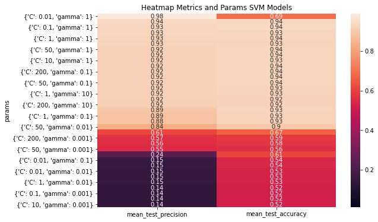

```python
data = bestModelsSVM[["params", "mean_test_precision", "mean_test_accuracy"]].set_index('params')
data = data.sort_values(by = ["mean_test_precision", "mean_test_accuracy"], ascending=False)
f, ax = plt.subplots(figsize=(9, 6))
sns.heatmap(data, annot=True, ax=ax, vmin=0.01, vmax=0.99).set(title='Heatmap Metrics and Params SVM Models')
plt.show()
```

**Implementación:** Con la mejor combinación de hiperparámetros encuentrada, entrenad un clasificador `SVM` (con _train_) y representar las fronteras de decisión con los puntos de _test_. Calcular el _accuracy_ del modelo obtenido sobre _test_ y la matriz de confusión. Puede utilizar `accuracy_score` y `confusion_matrix` de `metrics` de `sklearn`.

```python
data.head(2)
```

| params | mean_test_precision | mean_test_accuracy |
| --- | --- | --- |
| {'C': 0.01, 'gamma': 1} | 0.982843 | 0.69125 |
| {'C': 0.1, 'gamma': 10} | 0.942272 | 0.93875 |

Teniendo en cuenta el accuracy y la precisión el mejor modelo tiene como parámetros c =0.1 y gamma 10

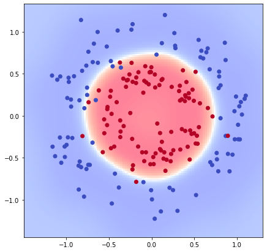

```python
bestModelSVM = SVC(C=0.1, gamma=10, probability=True)

bestModelSVM.fit(X_train, y_train)

plot_decision_boundaries(X_test["df_x"], X_test["df_y"], y_test, bestModelSVM)
```

```python
y_pred = bestModelSVM.predict(X_test)
accuracy_score(y_test, y_pred)
```

```
0.965
```

```python
target_names = [1,0]

cm = pd.DataFrame(
    confusion_matrix(y_test, y_pred),
    index= target_names,
    columns=target_names
)
cm
```

[output not shown]

```python
print(classification_report(y_test, y_pred))
```

```
              precision    recall  f1-score   support

           0       0.97      0.96      0.96        99
           1       0.96      0.97      0.97       101

    accuracy                           0.96       200
   macro avg       0.97      0.96      0.96       200
weighted avg       0.97      0.96      0.96       200
```

**Análisis:** Análisis del ejercicio. - Comentar los resultados de la búsqueda de los mejores hiperparámetros. - ¿Cómo son las fronteras de decisión? ¿Tiene sentido que tengan esta forma con el algoritmo utilizado? - ¿Cómo son las predicciones obtenidas sobre el conjunto de test?

### 1.4. Árboles de decisión

Los árboles de decisión son modelos predictivos formados por reglas binarias (si / no) con las que se consigue repartir las observaciones en función de sus atributos y predecir así el valor de la variable respuesta.

Los árboles pueden ser **clasificadores** (para clasificar clases, tales como nuestro ejemplo), o bien **regresores** (para predecir variables continuas).

#### Construcción de un árbol

La creación de las ramificaciones de los árboles se logra mediante el algoritmo de *recursive binary splitting*. Este algoritmo consta de tres pasos principales:

- El proceso se inicia en lo alto del árbol, donde todas las observaciones pertenecen a la misma región.
- Se identifican todos los posibles puntos de corte para cada uno de los predictores. Los puntos de corte son cada uno de sus niveles.
- se evalúan las posibles divisiones de cada predictor de acuerdo a una determinada medida. En el caso de los clasificadores se utilizan: *classification error rate*, Gini, entropía, chi-square.

#### Evitando el *overfitting*

El proceso de construcción de árboles descrito tiende a reducir rápidamente el error de entrenamiento, por lo que generalmente el modelo se ajusta muy bien a las observaciones utilizadas como entrenamiento (conjunto de *train*). Como consecuencia, los árboles de decisión tienden al *overfitting*.

Para prevenirlo, utilizaremos dos hiperparámetros:

- `max_depth`: la profundidad máxima del árbol. Exploraremos los valores entre 4 y 10.
- `min_samples_split`: el número mínimo de observaciones que debe tener una hoja del árbol para poder dividir. Exploraremos los valores: 2, 10, 20, 50 y 100.

**Implementación:** Calculad el valor óptimo de los hiperparámetros `max_depth` y `min_samples_split`. Utilizad una búsqueda de rejilla con validación cruzada para encontrar los valores óptimos. Para cada combinación de valores, calcular su promedio y la desviación estándar. Haced un _heatmap_ para visualizar la precisión según los diferentes valores de los hiperparámetros. Pódeis utilizar el módulo `GridSearchCV` de `sklearn` el cálculo de los mejores hiperparámetros con el clasificador `DecisionTreeClassifier` (de `tree` de `sklearn`), y `heatmap` de `Seaborn`.

```python
tree_params = {#'criterion':['gini','entropy'],
               'max_depth':[4,5,6,7,8,9,10],
               'min_samples_split': [2,10,20,50,100]
}

model_tree = GridSearchCV(DecisionTreeClassifier(),
                          param_grid = tree_params,
                          scoring = ['accuracy', 'precision'], refit=False,
                          #scoring = 'precision',
                          cv = 4, n_jobs=-1)

model_tree.fit(X_train, y_train)
```

```
GridSearchCV(cv=4, estimator=DecisionTreeClassifier(), n_jobs=-1,
             param_grid={'max_depth': [4, 5, 6, 7, 8, 9, 10],
                         'min_samples_split': [2, 10, 20, 50, 100]},
             refit=False, scoring=['accuracy', 'precision'])
```

```python
bestModelsPrecisionTrees = pd.DataFrame(model_tree.cv_results_)
bestModelsPrecisionTrees.head(2)
```

|  | mean_fit_time | std_fit_time | mean_score_time | std_score_time | param_max_depth | param_min_samples_split | params | split0_test_accuracy | split1_test_accuracy | split2_test_accuracy | ... | mean_test_accuracy | std_test_accuracy | rank_test_accuracy | split0_test_precision | split1_test_precision | split2_test_precision | split3_test_precision | mean_test_precision | std_test_precision | rank_test_precision |
| --- | --- | --- | --- | --- | --- | --- | --- | --- | --- | --- | --- | --- | --- | --- | --- | --- | --- | --- | --- | --- | --- |
| 0 | 0.011747 | 0.009392 | 0.013002 | 0.008397 | 4 | 2 | {'max_depth': 4, 'min_samples_split': 2} | 0.940 | 0.895 | 0.890 | ... | 0.90875 | 0.019486 | 22 | 0.931373 | 0.891089 | 0.875000 | 0.935484 | 0.908236 | 0.025867 | 19 |
| 1 | 0.012749 | 0.007395 | 0.009755 | 0.004821 | 4 | 10 | {'max_depth': 4, 'min_samples_split': 10} | 0.945 | 0.895 | 0.895 | ... | 0.91125 | 0.020425 | 16 | 0.940594 | 0.891089 | 0.883495 | 0.935484 | 0.912666 | 0.025579 | 16 |

2 rows × 21 columns

Top Model con base al accuracy

```python
bestModelsPrecisionTrees.sort_values(by = "rank_test_accuracy").head()
```

|  | mean_fit_time | std_fit_time | mean_score_time | std_score_time | param_max_depth | param_min_samples_split | params | split0_test_accuracy | split1_test_accuracy | split2_test_accuracy | ... | mean_test_accuracy | std_test_accuracy | rank_test_accuracy | split0_test_precision | split1_test_precision | split2_test_precision | split3_test_precision | mean_test_precision | std_test_precision | rank_test_precision |
| --- | --- | --- | --- | --- | --- | --- | --- | --- | --- | --- | --- | --- | --- | --- | --- | --- | --- | --- | --- | --- | --- |
| 34 | 0.005998 | 0.000707 | 0.006250 | 0.000435 | 10 | 100 | {'max_depth': 10, 'min_samples_split': 100} | 0.945 | 0.9 | 0.895 | ... | 0.9125 | 0.019526 | 1 | 0.940594 | 0.908163 | 0.883495 | 0.935484 | 0.916934 | 0.022907 | 1 |
| 29 | 0.007250 | 0.000829 | 0.006251 | 0.000830 | 9 | 100 | {'max_depth': 9, 'min_samples_split': 100} | 0.945 | 0.9 | 0.895 | ... | 0.9125 | 0.019526 | 1 | 0.940594 | 0.908163 | 0.883495 | 0.935484 | 0.916934 | 0.022907 | 1 |
| 28 | 0.008000 | 0.002916 | 0.008749 | 0.002488 | 9 | 50 | {'max_depth': 9, 'min_samples_split': 50} | 0.945 | 0.9 | 0.895 | ... | 0.9125 | 0.019526 | 1 | 0.940594 | 0.908163 | 0.883495 | 0.935484 | 0.916934 | 0.022907 | 1 |
| 3 | 0.008750 | 0.003345 | 0.007750 | 0.002046 | 4 | 50 | {'max_depth': 4, 'min_samples_split': 50} | 0.945 | 0.9 | 0.895 | ... | 0.9125 | 0.019526 | 1 | 0.940594 | 0.908163 | 0.883495 | 0.935484 | 0.916934 | 0.022907 | 1 |
| 4 | 0.008249 | 0.002861 | 0.005250 | 0.000434 | 4 | 100 | {'max_depth': 4, 'min_samples_split': 100} | 0.945 | 0.9 | 0.895 | ... | 0.9125 | 0.019526 | 1 | 0.940594 | 0.908163 | 0.883495 | 0.935484 | 0.916934 | 0.022907 | 1 |

5 rows × 21 columns

Top Models con base a la precisión

```python
bestModelsPrecisionTrees.sort_values(by = "rank_test_precision").head()
```

|  | mean_fit_time | std_fit_time | mean_score_time | std_score_time | param_max_depth | param_min_samples_split | params | split0_test_accuracy | split1_test_accuracy | split2_test_accuracy | ... | mean_test_accuracy | std_test_accuracy | rank_test_accuracy | split0_test_precision | split1_test_precision | split2_test_precision | split3_test_precision | mean_test_precision | std_test_precision | rank_test_precision |
| --- | --- | --- | --- | --- | --- | --- | --- | --- | --- | --- | --- | --- | --- | --- | --- | --- | --- | --- | --- | --- | --- |
| 34 | 0.005998 | 0.000707 | 0.006250 | 0.000435 | 10 | 100 | {'max_depth': 10, 'min_samples_split': 100} | 0.945 | 0.9 | 0.895 | ... | 0.9125 | 0.019526 | 1 | 0.940594 | 0.908163 | 0.883495 | 0.935484 | 0.916934 | 0.022907 | 1 |
| 19 | 0.008001 | 0.002345 | 0.007250 | 0.001640 | 7 | 100 | {'max_depth': 7, 'min_samples_split': 100} | 0.945 | 0.9 | 0.895 | ... | 0.9125 | 0.019526 | 1 | 0.940594 | 0.908163 | 0.883495 | 0.935484 | 0.916934 | 0.022907 | 1 |
| 14 | 0.006131 | 0.000740 | 0.009000 | 0.006365 | 6 | 100 | {'max_depth': 6, 'min_samples_split': 100} | 0.945 | 0.9 | 0.895 | ... | 0.9125 | 0.019526 | 1 | 0.940594 | 0.908163 | 0.883495 | 0.935484 | 0.916934 | 0.022907 | 1 |
| 13 | 0.013501 | 0.013593 | 0.005259 | 0.000555 | 6 | 50 | {'max_depth': 6, 'min_samples_split': 50} | 0.945 | 0.9 | 0.895 | ... | 0.9125 | 0.019526 | 1 | 0.940594 | 0.908163 | 0.883495 | 0.935484 | 0.916934 | 0.022907 | 1 |
| 23 | 0.007500 | 0.002180 | 0.008251 | 0.005069 | 8 | 50 | {'max_depth': 8, 'min_samples_split': 50} | 0.945 | 0.9 | 0.895 | ... | 0.9125 | 0.019526 | 1 | 0.940594 | 0.908163 | 0.883495 | 0.935484 | 0.916934 | 0.022907 | 1 |

5 rows × 21 columns

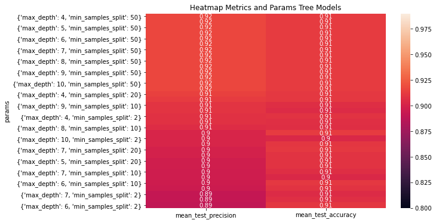

```python
datatrees = bestModelsPrecisionTrees[["params", "mean_test_precision", "mean_test_accuracy"]].set_index('params')
datatrees = datatrees.sort_values(by = ["mean_test_precision", "mean_test_accuracy"], ascending=False)
f, ax = plt.subplots(figsize=(9, 6))
sns.heatmap(datatrees, annot=True, ax=ax, vmin=0.80, vmax=0.99).set(title='Heatmap Metrics and Params Tree Models')
plt.show()
```

La performance de todos los modelos es homogénea

**Implementación:** Con la mejor combinación de hiperparámetros encontrados, entrenad un clasificador `DecisionTreeClassifier` (con `train`) y representar las fronteras de decisión con los puntos de `test`. Calcular el _accuracy_ del modelo obtenido sobre _test_ y la matriz de confusión. Puede utilizar `accuracy_score` y `confusion_matrix` de `metrics` de `sklearn`.

```python
datatrees.head(3)
```

| params | mean_test_precision | mean_test_accuracy |
| --- | --- | --- |
| {'max_depth': 4, 'min_samples_split': 50} | 0.916934 | 0.9125 |
| {'max_depth': 4, 'min_samples_split': 100} | 0.916934 | 0.9125 |
| {'max_depth': 5, 'min_samples_split': 50} | 0.916934 | 0.9125 |

```python
bestTree = DecisionTreeClassifier(max_depth=4, min_samples_split=50)
```

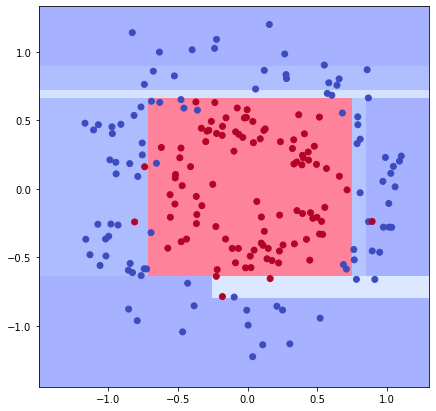

```python
bestTree.fit(X_train, y_train)

plot_decision_boundaries(X_test["df_x"], X_test["df_y"], y_test, bestTree)
```

```python
y_pred = bestTree.predict(X_test)
accuracy_score(y_test, y_pred)
```

```
0.92
```

```python
cm = pd.DataFrame(
    confusion_matrix(y_test, y_pred),
    index= target_names,
    columns=target_names
)
cm
```

[output not shown]

```python
print(classification_report(y_test, y_pred))
```

```
              precision    recall  f1-score   support

           0       0.94      0.90      0.92        99
           1       0.90      0.94      0.92       101

    accuracy                           0.92       200
   macro avg       0.92      0.92      0.92       200
weighted avg       0.92      0.92      0.92       200
```

**Análisis:** Análisis del ejercicio. - Comentar los resultados de la búsqueda de los mejores hiperparámetros. - ¿Cómo son las fronteras de decisión? ¿Tiene sentido que tengan esta forma con el algoritmo utilizado? - ¿Cómo son las predicciones obtenidas sobre el conjunto de test?

- Se probarón un total de 35 parámetros en la grid search. La mayoría de los modelos tienen un comportamiento similar, siendo el mejor el que utiliza {'max_depth': 4, 'min_samples_split': 50} como parámetrosç
- Las fronteras de decisión no son nada fluidas ni uniformes. Lo mencionado se debe a que cada rama del árbol representa un corte vertical en alguno de los ejes. Las zonas de incertidumbre se encuentran claramente dentro del espacio de la clase del circulo grande por lo que el modelo tiene problemas para detectar esta clase.
- En general las métricas de accuracy y precisión son altas pero menores en comparación a SVM y Knn